# ch7-Lab

S Zimine

12/5/2017

# Non-linear Modeling

## Polynomial Regrssions and Step functions

```r
require(ISLR)
data(Wage)

##poly regression and step fucntions
fit=lm(wage~poly(age,4),data=Wage) # only 1 poly age^4
print(coef(summary(fit)))
```

```
##                 Estimate Std. Error    t value     Pr(>|t|)
## (Intercept)    111.70361  0.7287409 153.283015 0.000000e+00
## poly(age, 4)1  447.06785 39.9147851  11.200558 1.484604e-28
## poly(age, 4)2 -478.31581 39.9147851 -11.983424 2.355831e-32
## poly(age, 4)3  125.52169 39.9147851   3.144742 1.678622e-03
## poly(age, 4)4  -77.91118 39.9147851  -1.951938 5.103865e-02
```

```r
#poly(..,raw=TRUE) to obtain directly age+age^2+age^3+age^4
fit2=lm(wage~poly(age,4,raw=T),data=Wage)
print(coef(summary(fit2))) #coefs r different but fitted values will be the same
```

```
##                             Estimate   Std. Error   t value     Pr(>|t|)
## (Intercept)            -1.841542e+02 6.004038e+01 -3.067172 0.0021802539
## poly(age, 4, raw = T)1  2.124552e+01 5.886748e+00  3.609042 0.0003123618
## poly(age, 4, raw = T)2 -5.638593e-01 2.061083e-01 -2.735743 0.0062606446
## poly(age, 4, raw = T)3  6.810688e-03 3.065931e-03  2.221409 0.0263977518
## poly(age, 4, raw = T)4 -3.203830e-05 1.641359e-05 -1.951938 0.0510386498
```

```r
##equivalent model using I() func
fit2a=lm(wage~age+I(age^2)+I(age^3)+I(age^4)
           ,data=Wage)

print(coef(summary(fit2a)))
```

```
##                  Estimate   Std. Error   t value     Pr(>|t|)
## (Intercept) -1.841542e+02 6.004038e+01 -3.067172 0.0021802539
## age          2.124552e+01 5.886748e+00  3.609042 0.0003123618
## I(age^2)    -5.638593e-01 2.061083e-01 -2.735743 0.0062606446
## I(age^3)     6.810688e-03 3.065931e-03  2.221409 0.0263977518
## I(age^4)    -3.203830e-05 1.641359e-05 -1.951938 0.0510386498
```

```r
#do the same more compactly (cbind makes a matrix)
fit2b=lm(wage~cbind(age,age^2,age^3,age^4)
            ,data=Wage)
print(coef(summary(fit2b)))
```

```
##                                         Estimate   Std. Error   t value
## (Intercept)                        -1.841542e+02 6.004038e+01 -3.067172
## cbind(age, age^2, age^3, age^4)age  2.124552e+01 5.886748e+00  3.609042
## cbind(age, age^2, age^3, age^4)    -5.638593e-01 2.061083e-01 -2.735743
## cbind(age, age^2, age^3, age^4)     6.810688e-03 3.065931e-03  2.221409
## cbind(age, age^2, age^3, age^4)    -3.203830e-05 1.641359e-05 -1.951938
##                                        Pr(>|t|)
## (Intercept)                        0.0021802539
## cbind(age, age^2, age^3, age^4)age 0.0003123618
## cbind(age, age^2, age^3, age^4)    0.0062606446
## cbind(age, age^2, age^3, age^4)    0.0263977518
## cbind(age, age^2, age^3, age^4)    0.0510386498
```

Create a chart with non-linear regression for the `wage` using polynomials of `age`

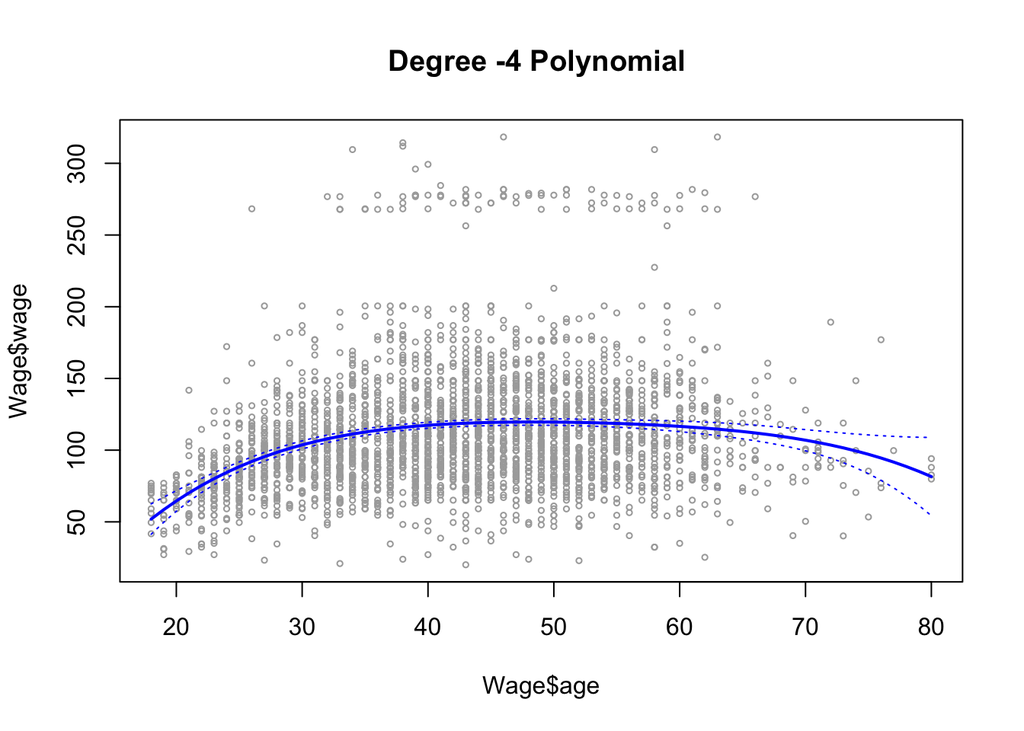

```r
#create a grid of values for age
agelims=range(Wage$age)
age.grid=seq(from=agelims[1],to=agelims[2])

preds=predict(fit,newdata=list(age=age.grid),se=TRUE)
se.bands=cbind(preds$fit+2*preds$se.fit
                  ,preds$fit-2*preds$se.fit )

##make the plot
plot(Wage$age,Wage$wage,xlim=agelims ,cex=.5
    ,col="darkgrey")
title("Degree -4 Polynomial ",outer=FALSE)
lines(age.grid,preds$fit,lwd=2,col="blue")
matlines(age.grid,se.bands,lwd=1,col="blue",lty=3)
```

As an exercices lets confirm that predicted values from `fit1` and `fit2` (these fits have different coefficients ) are the same.

```r
preds2=predict(fit2,newdata=list(age=age.grid),se=TRUE)
max(abs(preds$fit - preds2$fit))
```

```
## [1] 1.98952e-12
```

How to determine the minimum value of degrees of freedom in the `wage~age` model . Use `Anova()`.

```r
# 5 models
fit.1 <- lm(wage~age,data=Wage)
fit.2 <- lm(wage~poly(age,2),data=Wage)
fit.3 <- lm(wage~poly(age,3),data=Wage)
fit.4 <- lm(wage~poly(age,4),data=Wage)
fit.5 <- lm(wage~poly(age,5),data=Wage)
fit.6 <- lm(wage~poly(age,6),data=Wage)
anova(fit.1,fit.2,fit.3,fit.4,fit.5,fit.6)
```

```
## Analysis of Variance Table
##
## Model 1: wage ~ age
## Model 2: wage ~ poly(age, 2)
## Model 3: wage ~ poly(age, 3)
## Model 4: wage ~ poly(age, 4)
## Model 5: wage ~ poly(age, 5)
## Model 6: wage ~ poly(age, 6)
##   Res.Df     RSS Df Sum of Sq        F    Pr(>F)
## 1   2998 5022216
## 2   2997 4793430  1    228786 143.6636 < 2.2e-16 ***
## 3   2996 4777674  1     15756   9.8936  0.001675 **
## 4   2995 4771604  1      6070   3.8117  0.050989 .
## 5   2994 4770322  1      1283   0.8054  0.369565
## 6   2993 4766389  1      3932   2.4692  0.116201
## ---
## Signif. codes:  0 '***' 0.001 '**' 0.01 '*' 0.05 '.' 0.1 ' ' 1
```

We see that degree of 3 for age is sufficient for the model.

We can also make this conclusion by printing coefficients

```r
coef(summary(fit.6))
```

```
##                 Estimate Std. Error     t value     Pr(>|t|)
## (Intercept)    111.70361  0.7285859 153.3156280 0.000000e+00
## poly(age, 6)1  447.06785 39.9062945  11.2029408 1.447983e-28
## poly(age, 6)2 -478.31581 39.9062945 -11.9859739 2.290183e-32
## poly(age, 6)3  125.52169 39.9062945   3.1454107 1.674811e-03
## poly(age, 6)4  -77.91118 39.9062945  -1.9523532 5.098940e-02
## poly(age, 6)5  -35.81289 39.9062945  -0.8974246 3.695646e-01
## poly(age, 6)6   62.70772 39.9062945   1.5713741 1.162015e-01
```

It is still preferrable to use `ANOVA()` because it can compare models with multiple predictors e.g.

```r
fit.1=lm(wage~education+age,data=Wage)
fit.2=lm(wage~education+poly(age,2),data=Wage)
fit.3=lm(wage~education+poly(age,3),data=Wage)
fit.4=lm(wage~education+poly(age,4),data=Wage)

anova(fit.1,fit.2,fit.3, fit.4)
```

```
## Analysis of Variance Table
##
## Model 1: wage ~ education + age
## Model 2: wage ~ education + poly(age, 2)
## Model 3: wage ~ education + poly(age, 3)
## Model 4: wage ~ education + poly(age, 4)
##   Res.Df     RSS Df Sum of Sq        F  Pr(>F)
## 1   2994 3867992
## 2   2993 3725395  1    142597 114.6595 < 2e-16 ***
## 3   2992 3719809  1      5587   4.4921 0.03413 *
## 4   2991 3719777  1        32   0.0255 0.87308
## ---
## Signif. codes:  0 '***' 0.001 '**' 0.01 '*' 0.05 '.' 0.1 ' ' 1
```

### Multiple logistic regression

#### Response is a probability of folks who make > 250 K

```r
fit <- glm(I(wage>250)~poly(age,4)
          ,data=Wage,family=binomial)  #for logit
preds <- predict(fit, newdata=list(age=age.grid),se=TRUE)

## for logit standard errors band
pfit <- exp(preds$fit) / (1+exp(preds$fit))
se.bands.logit <- cbind( preds$fit+2*preds$se.fit
                        ,preds$fit-2*preds$se.fit)

se.bands <- exp(se.bands.logit)/(1+exp(se.bands.logit))

##compute predictions directly as a probability
ppreds <- predict(fit, newdata=list(age=age.grid)
                ,type="response" )

max(abs(pfit-ppreds))
```

```
## [1] 0
```

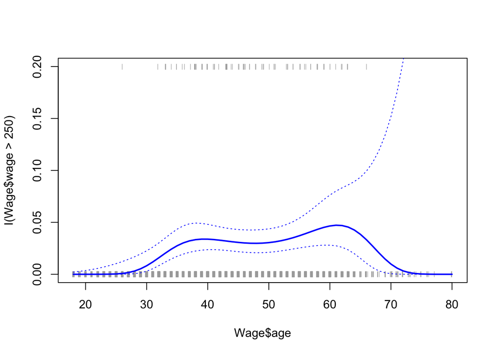

```r
##plotting
plot(Wage$age, I(Wage$wage>250), xlim=agelims, type="n", ylim=c(0,.2))
points(jitter(Wage$age), I((Wage$wage>250)/5),cex=.5
       ,pch="|",col =" darkgrey ")
lines(age.grid,pfit,lwd=2, col="blue")
matlines(age.grid,se.bands,lwd=1,col="blue",lty=3)
```

#### Step function

```r
table(cut(Wage$age,6))
```

```
##
## (17.9,28.3] (28.3,38.7]   (38.7,49]   (49,59.3] (59.3,69.7] (69.7,80.1]
##         390         737        1022         641         175          35
```

```r
fit <- lm(wage~cut(age,6), data=Wage)
coef(summary(fit))
```

```
##                        Estimate Std. Error   t value      Pr(>|t|)
## (Intercept)            84.74008   2.038454 41.570753 1.401505e-298
## cut(age, 6)(28.3,38.7] 25.92636   2.520747 10.285190  2.083373e-24
## cut(age, 6)(38.7,49]   34.03430   2.396034 14.204434  2.300029e-44
## cut(age, 6)(49,59.3]   32.55713   2.585243 12.593452  1.790348e-35
## cut(age, 6)(59.3,69.7] 32.79018   3.662741  8.952361  5.971515e-19
## cut(age, 6)(69.7,80.1] 11.21129   7.103321  1.578317  1.145984e-01
```

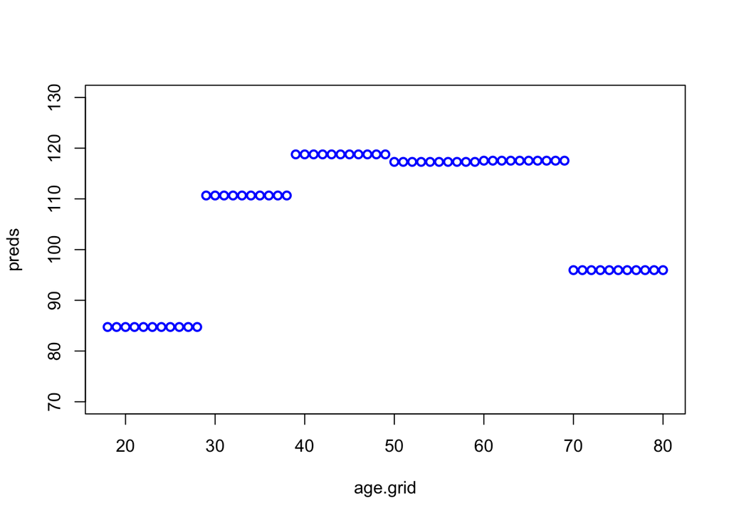

```r
preds <- predict(fit, newdata=list(age=age.grid))

#plot
plot(age.grid, preds, ylim=c(70,130),  lwd=2,col="blue", lty=1)
```

# Splines

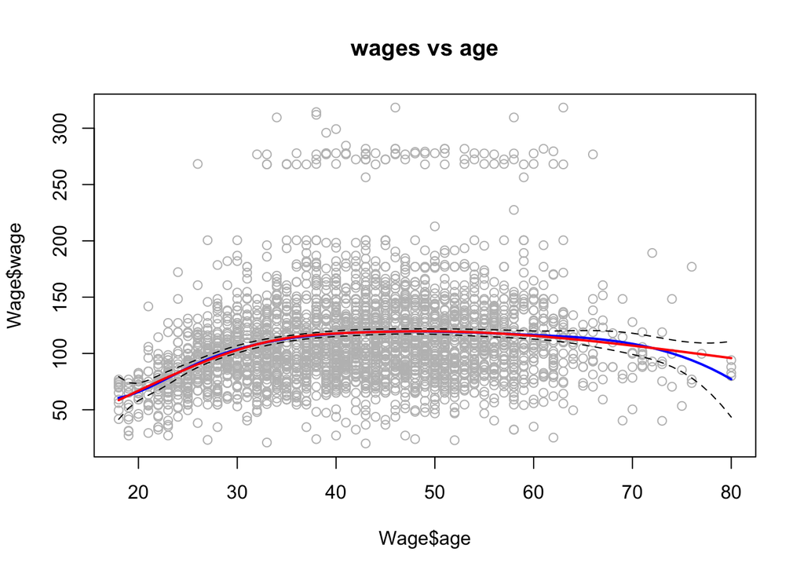

```r
library(splines)
#here we specify knots
fit <- lm(wage~bs(age,knots=c(25,40,60)),data=Wage)

pred <- predict(fit,newdata=list(age=age.grid),se=T)

plot(Wage$age,Wage$wage,col="gray", main="wages vs age")
lines(age.grid,pred$fit,lwd=2, col="blue")
lines(age.grid,pred$fit+2*pred$se ,lty="dashed")
lines(age.grid,pred$fit-2*pred$se ,lty="dashed")

##using natural splines
fit2 <- lm(wage~ns(age,df=4),data=Wage)
pred2 <- predict(fit2,newdata=list(age=age.grid),se=T)
lines(age.grid,pred2$fit,lwd=2,col="red")
```

A spline with 3 knots have 7 degrees of freedom, Intecept + 3 degrees of cubic polynomial + 3 truncated power functions.

### With smoothing spline

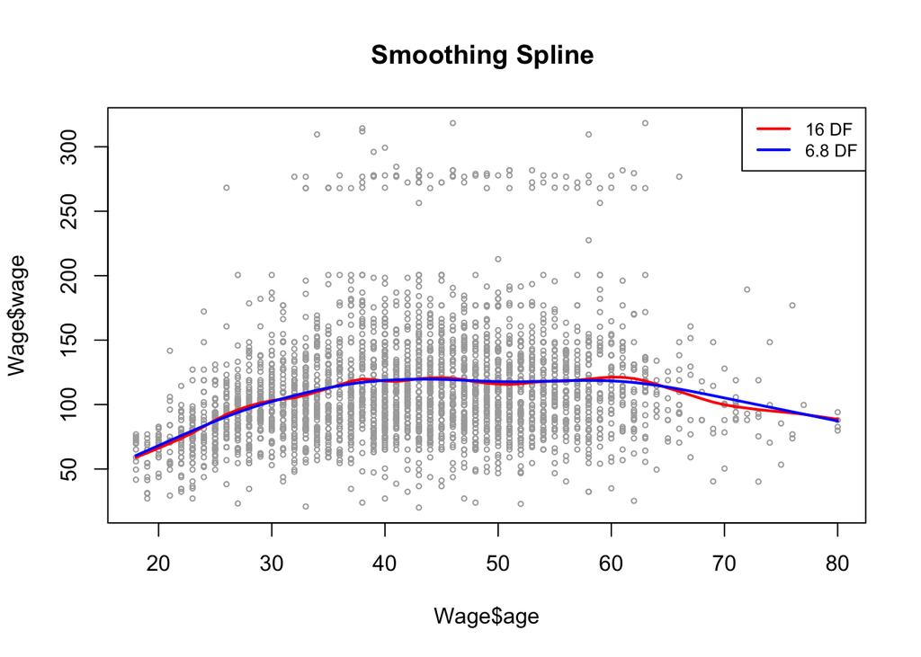

```r
plot(Wage$age,Wage$wage,xlim=agelims,cex=.5,col="darkgrey")
title ("Smoothing Spline ")
fit <- smooth.spline(Wage$age,Wage$wage,df=16)
fit2 <- smooth.spline(Wage$age,Wage$wage,cv=TRUE)
lines(fit,col="red",lwd=2)
lines(fit2,col="blue",lwd=2)
legend("topright",legend=c("16 DF","6.8 DF")
        ,col=c("red","blue"),lty=1,lwd=2,cex=.8)
```

```r
## this is determined by cross-vaidation
fit2$df
```

```
## [1] 6.794596
```

### Local regression (loess)

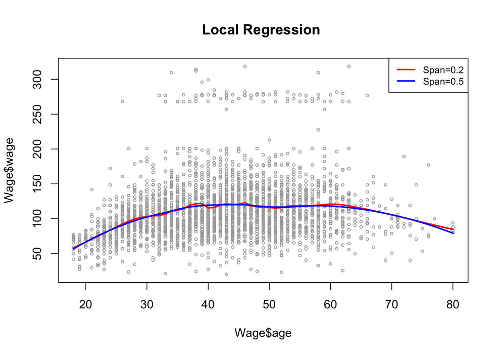

```r
plot(Wage$age,Wage$wage,xlim=agelims
    ,cex=.5,col="darkgrey")
title ("Local Regression ")
fit=loess(wage~age,span=.2,data=Wage) #each neighbourhood has 20% of obs
fit2=loess(wage~age,span=.5,data=Wage) # each neighbourhood has 50% of obs
lines(age.grid,predict(fit,data.frame(age=age.grid)), col="red",lwd=2)
lines(age.grid,predict(fit2,data.frame(age=age.grid)), col="blue",lwd=2)
legend("topright",legend=c("Span=0.2","Span=0.5")
      ,col=c("red","blue"),lty=1,lwd=2,cex=.8)
```

Span=0.2, 0.5 : each neighborhood contains 20% or 50% of observations.

# GAMs

General Additive models.

WE now fit a GAM to predict `wage` using natural splines of `year` and `age` and treating `education` as a qualitative predictor.

```r
gam1<-lm(wage~ns(year,4)+ns(age,5)+education,data=Wage)
library(gam)
```

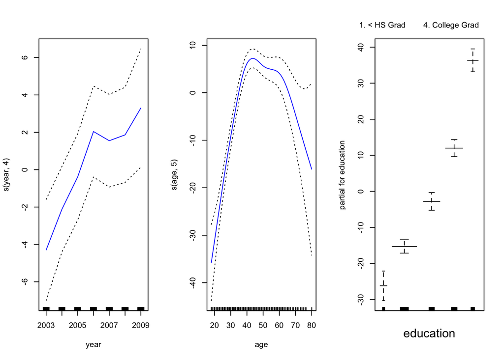

```r
#s func for smoothing spline
gam.m3<-gam(wage~s(year,4)+s(age,5)+education ,data=Wage)

par(mfrow=c(1,3))
plot(gam.m3, se=TRUE,col="blue")
```

We can also use a plot from gam pkg

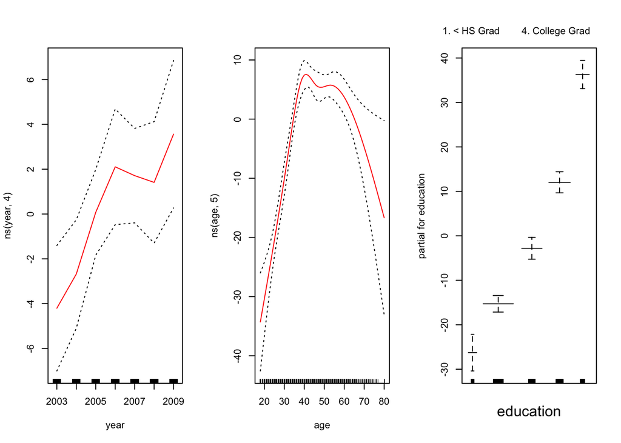

```r
par(mfrow=c(1,3))
plot.Gam(gam1,se=TRUE,col="red")
```

We can compare gam models using `anova()`

```r
gam.m1 <- gam(wage~s(age,5)+education ,data=Wage)
gam.m2 <- gam(wage~year+s(age ,5)+education ,data=Wage)
anova(gam.m1,gam.m2,gam.m3,test="F")
```

```
## Analysis of Deviance Table
##
## Model 1: wage ~ s(age, 5) + education
## Model 2: wage ~ year + s(age, 5) + education
## Model 3: wage ~ s(year, 4) + s(age, 5) + education
##   Resid. Df Resid. Dev Df Deviance       F    Pr(>F)
## 1      2990    3711731
## 2      2989    3693842  1  17889.2 14.4771 0.0001447 ***
## 3      2986    3689770  3   4071.1  1.0982 0.3485661
## ---
## Signif. codes:  0 '***' 0.001 '**' 0.01 '*' 0.05 '.' 0.1 ' ' 1
```

From p-values model 2 is preferred.

```r
summary(gam.m3)
```

```
##
## Call: gam(formula = wage ~ s(year, 4) + s(age, 5) + education, data = Wage)
## Deviance Residuals:
##     Min      1Q  Median      3Q     Max
## -119.43  -19.70   -3.33   14.17  213.48
##
## (Dispersion Parameter for gaussian family taken to be 1235.69)
##
##     Null Deviance: 5222086 on 2999 degrees of freedom
## Residual Deviance: 3689770 on 2986 degrees of freedom
## AIC: 29887.75
##
## Number of Local Scoring Iterations: 2
##
## Anova for Parametric Effects
##              Df  Sum Sq Mean Sq F value    Pr(>F)
## s(year, 4)    1   27162   27162  21.981 2.877e-06 ***
## s(age, 5)     1  195338  195338 158.081 < 2.2e-16 ***
## education     4 1069726  267432 216.423 < 2.2e-16 ***
## Residuals  2986 3689770    1236
## ---
## Signif. codes:  0 '***' 0.001 '**' 0.01 '*' 0.05 '.' 0.1 ' ' 1
##
## Anova for Nonparametric Effects
##             Npar Df Npar F  Pr(F)
## (Intercept)
## s(year, 4)        3  1.086 0.3537
## s(age, 5)         4 32.380 <2e-16 ***
## education
## ---
## Signif. codes:  0 '***' 0.001 '**' 0.01 '*' 0.05 '.' 0.1 ' ' 1
```

To compute predictions

```r
preds <- predict(gam.m2,newdata=Wage)
```

```r
gam.lo.i <- gam(wage~lo(year,age,span=0.5)+education,data=Wage)
```

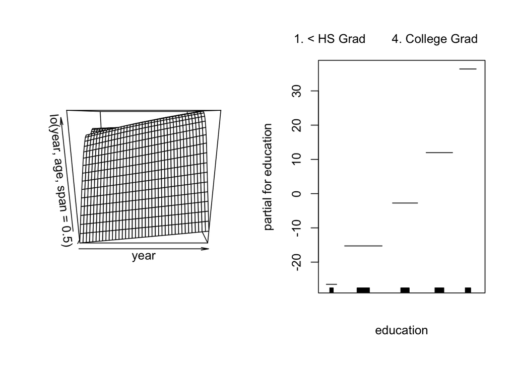

```r
library(akima)
par( mfrow=c(1,2))
plot(gam.lo.i)
```

For logistic regression

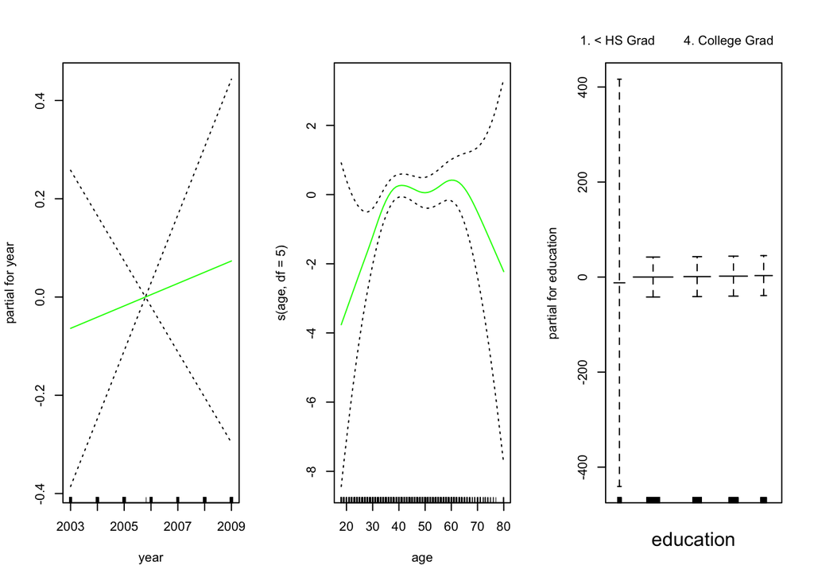

```r
gam.lr <- gam(I(wage>250)~year+s(age,df=5)+education
              ,data=Wage, family=binomial )
par(mfrow=c(1,3))
plot(gam.lr, se=TRUE, col="green")
```

```r
table(Wage$education, I(Wage$wage>250))
```

```
##
##                      FALSE TRUE
##   1. < HS Grad         268    0
##   2. HS Grad           966    5
##   3. Some College      643    7
##   4. College Grad      663   22
##   5. Advanced Degree   381   45
```

To cut out the education category of < HS grad

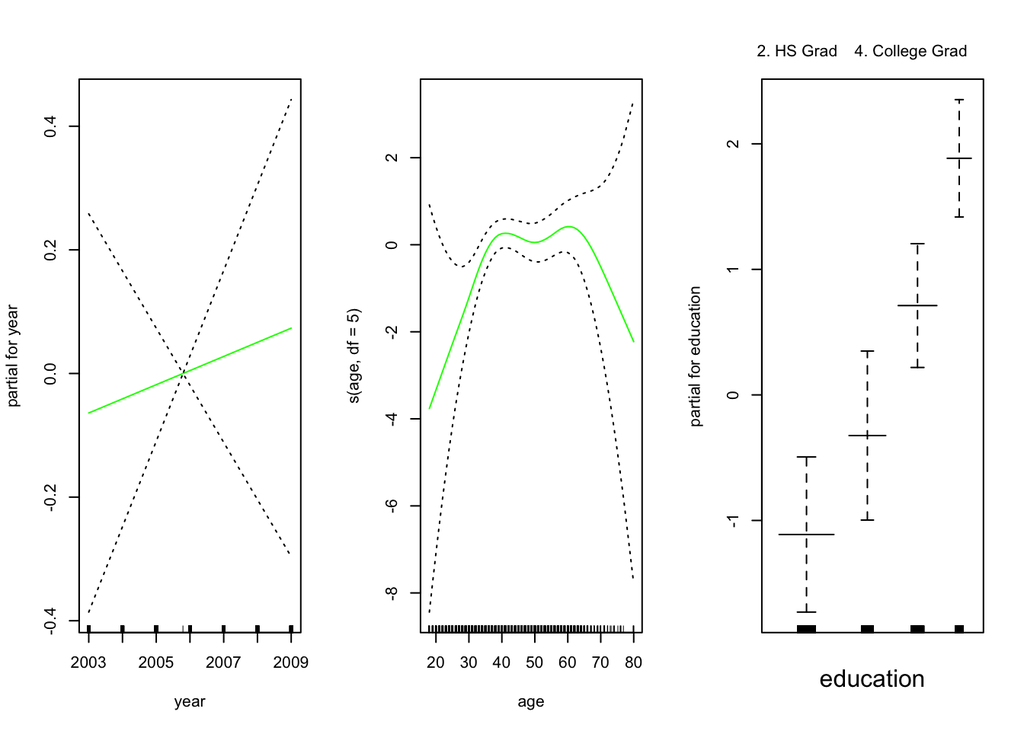

```r
gam.lr.s=gam(I(wage>250)~year+s(age,df=5)+education,family= binomial,data=Wage,subset=(education!="1. < HS Grad"))
par(mfrow=c(1,3))
plot(gam.lr.s, se=TRUE, col="green")
```